# Introduction to Programming

Hugo Lhuillier

Master in Economics, Sciences Po

# Remember: data visualization

# Exercice

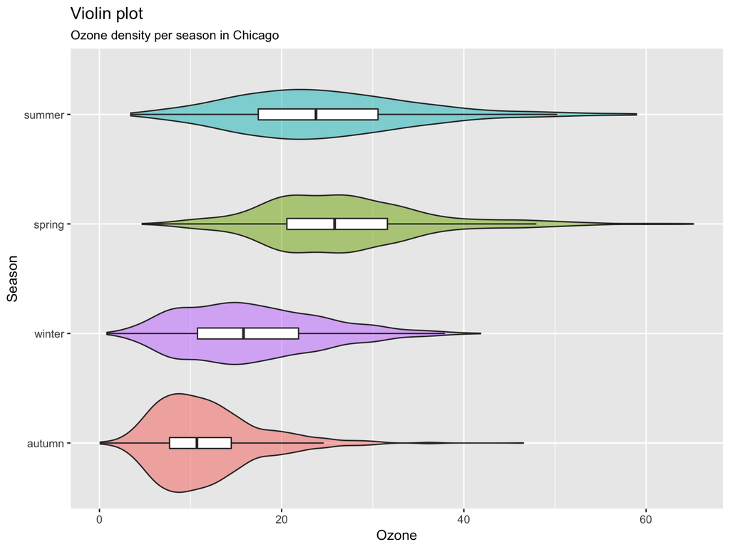

# Solution

```r
setwd("/Users/hugolhuillier/Dropbox/Teaching/intro-prog/2017-2018/4-8-r/lecture8")
nmmaps <-read.csv("chicago-nmmaps.csv", as.is=T)

ggplot(nmmaps, aes(x=season, y=o3)) +
  geom_violin(alpha=0.5, aes(fill = season), show.legend = F) +
  geom_boxplot(width = 0.1, outlier.shape=NA) +
  scale_x_discrete(limits=c("autumn", "winter", "spring", "summer")) +
  coord_flip() +
  labs( title = "Violin plot",
      subtitle="Ozone density per season in Chicago",
      y="Ozone",
      x="Season")
```

# Resources

- [This tutorial](http://www.sthda.com/english/wiki/be-awesome-in-ggplot2-a-practical-guide-to-be-highly-effective-r-software-and-data-visualization)
- [This cheat seet](https://www.rstudio.com/wp-content/uploads/2015/03/ggplot2-cheatsheet.pdf)
- [Thematic maps with ggplot2](https://timogrossenbacher.ch/2016/12/beautiful-thematic-maps-with-ggplot2-only/)

# Data Transformation with `dplyr`

# Introduction to `dplyr`

- All the data we used in the previous lecture were extremely well shaped

```r
mpg
```

```
## # A tibble: 234 x 11
##    manufacturer model    displ  year   cyl trans   drv     cty   hwy fl
##    <chr>        <chr>    <dbl> <int> <int> <chr>   <chr> <int> <int> <chr>
##  1 audi         a4        1.80  1999     4 auto(l… f        18    29 p
##  2 audi         a4        1.80  1999     4 manual… f        21    29 p
##  3 audi         a4        2.00  2008     4 manual… f        20    31 p
##  4 audi         a4        2.00  2008     4 auto(a… f        21    30 p
##  5 audi         a4        2.80  1999     6 auto(l… f        16    26 p
##  6 audi         a4        2.80  1999     6 manual… f        18    26 p
##  7 audi         a4        3.10  2008     6 auto(a… f        18    27 p
##  8 audi         a4 quat…  1.80  1999     4 manual… 4        18    26 p
##  9 audi         a4 quat…  1.80  1999     4 auto(l… 4        16    25 p
## 10 audi         a4 quat…  2.00  2008     4 manual… 4        20    28 p
## # ... with 224 more rows, and 1 more variable: class <chr>
```

- In this section: learn how to group, filter, summarize, create variables etc., with the `dyplr` package

# Why bother?

- Without the proper tools, data analysis is: 5% analysis, 95% cleaning and re-organizing data
- With the proper tools, can bring the ratio to a solid 40-60

[figure not shown]

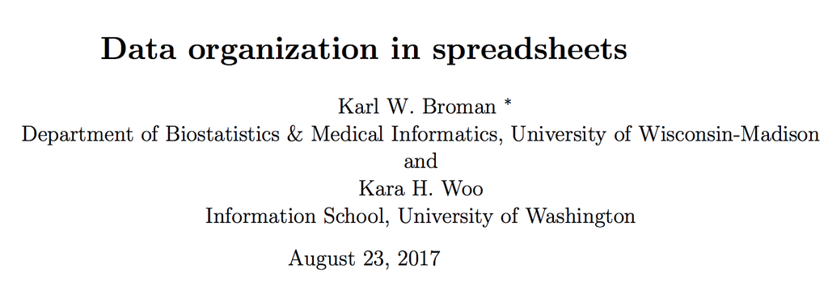

- `dyplr` provides functions that are much more efficient and intuitive than the base R ones

# Getting started

- Explore the basics of data manipulation witht the `nycflights13` data set

```r
library(tidyverse)
library(nycflights13)
```

```r
flights
```

```
## # A tibble: 336,776 x 19
##     year month   day dep_time sched_dep_time dep_delay arr_time
##    <int> <int> <int>    <int>          <int>     <dbl>    <int>
##  1  2013     1     1      517            515        2.      830
##  2  2013     1     1      533            529        4.      850
##  3  2013     1     1      542            540        2.      923
##  4  2013     1     1      544            545       -1.     1004
##  5  2013     1     1      554            600       -6.      812
##  6  2013     1     1      554            558       -4.      740
##  7  2013     1     1      555            600       -5.      913
##  8  2013     1     1      557            600       -3.      709
##  9  2013     1     1      557            600       -3.      838
## 10  2013     1     1      558            600       -2.      753
## # ... with 336,766 more rows, and 12 more variables: sched_arr_time <int>,
## #   arr_delay <dbl>, carrier <chr>, flight <int>, tailnum <chr>,
## #   origin <chr>, dest <chr>, air_time <dbl>, distance <dbl>, hour <dbl>,
## #   minute <dbl>, time_hour <dttm>
```

- `tibbles` are data frames tweaked to work better in the tidyverse enviromnent
- To view the entire data set, `View(flights)`

# `tibbles` vs. `data.frames`: raw introduction

- `tibbles` do not print the entire table when called in the console
- `tibbles` automatically prints info on the data types contained

```r
head(flights)
```

```
## # A tibble: 6 x 19
##    year month   day dep_time sched_dep_time dep_delay arr_time
##   <int> <int> <int>    <int>          <int>     <dbl>    <int>
## 1  2013     1     1      517            515        2.      830
## 2  2013     1     1      533            529        4.      850
## 3  2013     1     1      542            540        2.      923
## 4  2013     1     1      544            545       -1.     1004
## 5  2013     1     1      554            600       -6.      812
## 6  2013     1     1      554            558       -4.      740
## # ... with 12 more variables: sched_arr_time <int>, arr_delay <dbl>,
## #   carrier <chr>, flight <int>, tailnum <chr>, origin <chr>, dest <chr>,
## #   air_time <dbl>, distance <dbl>, hour <dbl>, minute <dbl>,
## #   time_hour <dttm>
```

```r
head(nmmaps)
```

```
##   city       date death temp dewpoint     pm10       o3 time season
## 1 chic 1987-01-01   130 31.5   31.500 27.79119 4.025928    1 winter
## 2 chic 1987-01-02   150 33.0   29.875       NA 4.579652    2 winter
## 3 chic 1987-01-03   101 33.0   27.375 33.67382 3.400928    3 winter
## 4 chic 1987-01-04   135 29.0   28.625 40.79119 3.942595    4 winter
## 5 chic 1987-01-05   126 32.0   28.875       NA 4.400928    5 winter
## 6 chic 1987-01-06   130 40.0   35.125 41.79119 5.984261    6 winter
```

# `tibbles` data types

- `int`: integers
- `dbl`: real numbers
- `chr`: characters & strings
- `dttm`: data-times (date + time)
- `lgl`: logical
- `fctr`: factors
- `date`: dates

# `dplyr`: the 6 key functions

- In this section, we’ll learn how to:
  1. pick observations based on their values (`filter()`)
  2. reorder the rows (`arrange()`)
  3. pick variables by their names (`select()`)
  4. create new variables with functions of existing variables (`mutate()`)
  5. collapse many values down to a single summary (`summarize()`)
- Can be used in conjunction wtih `group_by()` to operate only on a subset of the data set

# `dyplyr`: template

```r
new_data <- <dyplr_function>(<raw_data>, <names_of_the_variables_to_work_with>...)
```

# Filter

# Filter rows with `filter()`

- `filter()`: subset observations based on their values
- Uses logicals to select the observations, and returns a new `tibble` (i.e., no modification in place)

```r
# select all flights on January 1st
filter(flights, month == 1, day == 1)
```

```
## # A tibble: 842 x 19
##     year month   day dep_time sched_dep_time dep_delay arr_time
##    <int> <int> <int>    <int>          <int>     <dbl>    <int>
##  1  2013     1     1      517            515        2.      830
##  2  2013     1     1      533            529        4.      850
##  3  2013     1     1      542            540        2.      923
##  4  2013     1     1      544            545       -1.     1004
##  5  2013     1     1      554            600       -6.      812
##  6  2013     1     1      554            558       -4.      740
##  7  2013     1     1      555            600       -5.      913
##  8  2013     1     1      557            600       -3.      709
##  9  2013     1     1      557            600       -3.      838
## 10  2013     1     1      558            600       -2.      753
## # ... with 832 more rows, and 12 more variables: sched_arr_time <int>,
## #   arr_delay <dbl>, carrier <chr>, flight <int>, tailnum <chr>,
## #   origin <chr>, dest <chr>, air_time <dbl>, distance <dbl>, hour <dbl>,
## #   minute <dbl>, time_hour <dttm>
```

# `filter()` & logicals

- By default, conditionl arguments are combined with $\cap$ within `filter`
- If want to use $\cup$ or more complicated structure, hardcode it

```r
filter(flights, month == 11, month == 12)
```

```
## # A tibble: 0 x 19
## # ... with 19 variables: year <int>, month <int>, day <int>,
## #   dep_time <int>, sched_dep_time <int>, dep_delay <dbl>, arr_time <int>,
## #   sched_arr_time <int>, arr_delay <dbl>, carrier <chr>, flight <int>,
## #   tailnum <chr>, origin <chr>, dest <chr>, air_time <dbl>,
## #   distance <dbl>, hour <dbl>, minute <dbl>, time_hour <dttm>
```

```r
# flights that departed in November or December!
filter(flights, month == 11 | month == 12)
```

```
## # A tibble: 55,403 x 19
##     year month   day dep_time sched_dep_time dep_delay arr_time
##    <int> <int> <int>    <int>          <int>     <dbl>    <int>
##  1  2013    11     1        5           2359        6.      352
##  2  2013    11     1       35           2250      105.      123
##  3  2013    11     1      455            500       -5.      641
##  4  2013    11     1      539            545       -6.      856
##  5  2013    11     1      542            545       -3.      831
##  6  2013    11     1      549            600      -11.      912
##  7  2013    11     1      550            600      -10.      705
##  8  2013    11     1      554            600       -6.      659
##  9  2013    11     1      554            600       -6.      826
## 10  2013    11     1      554            600       -6.      749
## # ... with 55,393 more rows, and 12 more variables: sched_arr_time <int>,
## #   arr_delay <dbl>, carrier <chr>, flight <int>, tailnum <chr>,
## #   origin <chr>, dest <chr>, air_time <dbl>, distance <dbl>, hour <dbl>,
## #   minute <dbl>, time_hour <dttm>
```

# `filter()` & variables

- In the previous example, had to restate twice `month`: `month == 11 | month == 12`
- Shortcut: `%in%` command

```r
# equivalent to month %in% c(10,11,12)
filter(flights, month %in% 10:12)
```

```
## # A tibble: 84,292 x 19
##     year month   day dep_time sched_dep_time dep_delay arr_time
##    <int> <int> <int>    <int>          <int>     <dbl>    <int>
##  1  2013    10     1      447            500      -13.      614
##  2  2013    10     1      522            517        5.      735
##  3  2013    10     1      536            545       -9.      809
##  4  2013    10     1      539            545       -6.      801
##  5  2013    10     1      539            545       -6.      917
##  6  2013    10     1      544            550       -6.      912
##  7  2013    10     1      549            600      -11.      653
##  8  2013    10     1      550            600      -10.      648
##  9  2013    10     1      550            600      -10.      649
## 10  2013    10     1      551            600       -9.      727
## # ... with 84,282 more rows, and 12 more variables: sched_arr_time <int>,
## #   arr_delay <dbl>, carrier <chr>, flight <int>, tailnum <chr>,
## #   origin <chr>, dest <chr>, air_time <dbl>, distance <dbl>, hour <dbl>,
## #   minute <dbl>, time_hour <dttm>
```

# `filter()` & `NA`

- Remember: `NA` = missing value
- `NA` are very contagious

```r
NA + 10
```

```
## [1] NA
```

```r
NA > 1
```

```
## [1] NA
```

```r
filter(flights, is.na(x) | (month == 1 & day == 1))
```

# Exercice

- Plot the density of arrival delay for the flights operated by United (`UA`), American (`AA`) or Delta (`DL`)
- See that ugly right tail? Remove it by plotting only the flights operated by United (`UA`), American (`AA`) or Delta (`DL`) with arrival delays smaller than its 99th percentile (look up the `quantile()` function)

# Solution

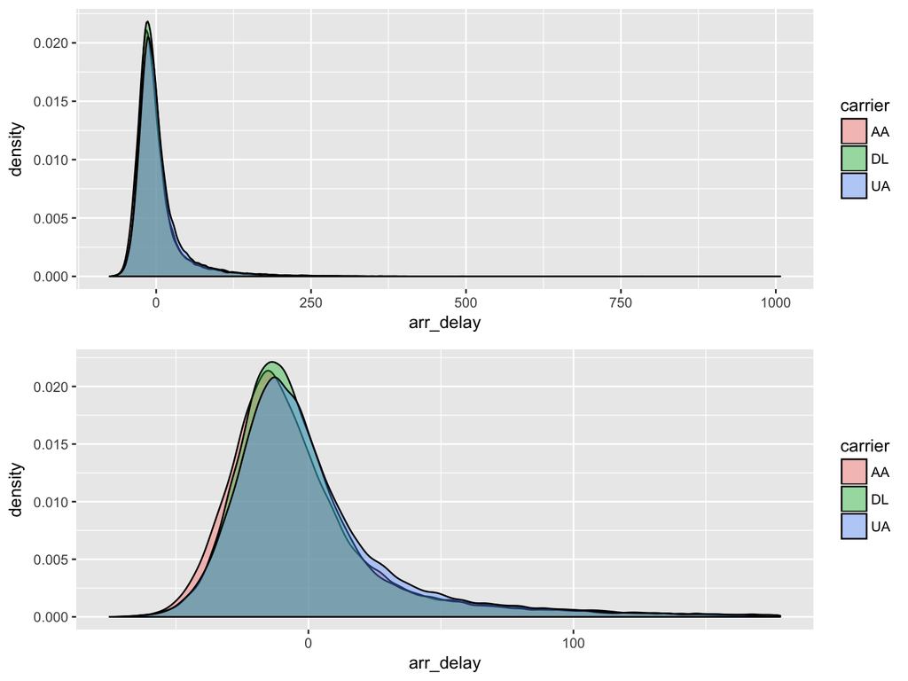

```r
# take only the data for the three companies
flights_comp <- filter(flights, carrier %in% c("UA","AA","DL"))
ggplot(flights_comp) +
  geom_density(aes(x = arr_delay, fill = carrier), color = "black", alpha = 0.4)
# consider only the data for arrival delays < 99th percentile
flights_comp_99 <- filter(flights_comp, arr_delay <= quantile(flights_comp$arr_delay, 0.99, na.rm = T))
ggplot(flights_comp_99) +
  geom_density(aes(x = arr_delay, fill = carrier), color = "black", alpha = 0.4)
```

# Arrange rows

# Arrange rows with arrange

- `arrange()` change the order of the **rows**
- Can order by one or multiple columns (then the order matters!)
- By default: ascending orders. Use `desc()` to reorder in descending order

```r
# arrange the data by year, then month, then day
arrange(flights, year, month, day)
```

```
## # A tibble: 336,776 x 19
##     year month   day dep_time sched_dep_time dep_delay arr_time
##    <int> <int> <int>    <int>          <int>     <dbl>    <int>
##  1  2013     1     1      517            515        2.      830
##  2  2013     1     1      533            529        4.      850
##  3  2013     1     1      542            540        2.      923
##  4  2013     1     1      544            545       -1.     1004
##  5  2013     1     1      554            600       -6.      812
##  6  2013     1     1      554            558       -4.      740
##  7  2013     1     1      555            600       -5.      913
##  8  2013     1     1      557            600       -3.      709
##  9  2013     1     1      557            600       -3.      838
## 10  2013     1     1      558            600       -2.      753
## # ... with 336,766 more rows, and 12 more variables: sched_arr_time <int>,
## #   arr_delay <dbl>, carrier <chr>, flight <int>, tailnum <chr>,
## #   origin <chr>, dest <chr>, air_time <dbl>, distance <dbl>, hour <dbl>,
## #   minute <dbl>, time_hour <dttm>
```

```r
# arrange(flights, year, month, day) different from arrange(flights, year, day, month)
```

- Missing values are always sorted at the end